# UTLK Solids Methods review

T.Hooker

9 August, 2019

**Project Root Path** :: `"U:\ENG_WQ\tobyhooker\DATA MANAGEMENT & QA\DATA.Projects\UtahLake_chemMethods\UTLK_solids_meth_r"`

```r
#options(table_counter=FALSE)
tidy_package <- c("plyr", "dplyr", "tidyr", "magrittr", "htmlTable")
# suppressPackageStartupMessages(library("tidy"))
if(!"tidyr" %in% (.packages())) {invisible(lapply(tidy_package, function(x) suppressMessages(library(x, character.only=T, quietly = T, warn.conflicts = F))))}
##
graph_package <- c("ggplot2", "scales")
if(!"ggplot2" %in% (.packages())) {invisible(lapply(graph_package, library, character.only=T, quietly = T, warn.conflicts = F))}
##
options(scipen = 999, digits = 4, stringsAsFactors = FALSE, keep.source = TRUE)
##
# startwork.date <- format(Sys.Date(), "%y%m%d")
knitr::opts_chunk$set(cache=TRUE)
```

## 0.0 Notes

[190808] :: Utah Lake Science Panel (Dr. Mitch Hogsett) posed question of exact procedure and naming-convention for aqueous volatile solids concentration, TVS versus VSS. TSS from SM 2540D / EPA 160.2; Volatile solids from SM 2540E and EPA 160.4. [email].

Questions to address::

1. Which methods for TVS (etc.) are used in UTLK dataset?
2. Which methods for TVS are provided by UPHL?
3. Is there disagreement b/w method-IDs and characteristic names that must be reconciled?
4. Is it necessary / worthwhile to do so?

Steps:

1. Extract all solids data from AWQMS from UTLK sites
2. Eval Meth-Params

## 1.0 Data import

1. UTLK Sites

```r
utlk_sites
```

```
 [1] "4917300" "4917370" "4917390" "4917500" "4917510" "4917530" "4917770" "4917620" "4917310" "4917320"
[11] "4917330" "4917340" "4917380" "4917400" "4917410" "4917420" "4917520" "4917700" "4917710" "4917450"
[21] "4917600" "4917433" "4917470"
```

Go to : https://awqms.utah.gov/Homepage.aspx  
Login as: thooker // pw  
Navigate :

- Metadata
- Monitoring Locations
- [select] Search
- [select] Export to Excel
- -complete-
3. Import AWQMS data

```r
# file.01  <- choose.files(caption="Select _working_ DATA file [*.xlsx]", multi = FALSE)
data01 <- openxlsx::read.xlsx(file.01, sheet=1, startRow = 2,
                              rowNames=FALSE, check.names = T)
```

4. Cleanup and Tune
- Sampling and Analysis Date/Time

```r
data01$Activity.Start.Date <- as.Date(data01$Activity.Start.Date, origin="1899-12-30")
data01$Analysis.Start.Date <- as.Date(data01$Analysis.Start.Date, origin="1899-12-30")
data01$Activity.Start.Time <- as.character(chron::times((data01$Activity.Start.Time - as.integer(data01$Activity.Start.Time))))
data01$Analysis.Start.Time <- as.character(chron::times((data01$Analysis.Start.Time - as.integer(data01$Analysis.Start.Time))))
```

- Filename :: Standard Export 24260_utlkSOLIDS.xlsx
- Path :: C:/R_PROJECT_WORK_4
- Datafile has :: 2586 records & 191 fields
- Record Data Range :: From 1978-08-31 to 2018-11-20
- Record Sample-Time Range :: From [07:30:00] to [17:35:00]

### 1.1 Trim datafile

**Fields to Keep from AWQMS Standard Export**

```r
awqms_export_fields_tokeep <- c("Organization.ID","Activity.ID","Activity.Type","Activity.Media","Activity.Start.Date", "Activity.Start.Time", "Activity.Relative.Depth","Activity.Depth.Height","Activity.Depth.Height.Unit","Activity.Top.Depth.Height","Activity.Top.Depth.Height.Unit","Activity.Bottom.Depth.Height","Activity.Bottom.Depth.Height.Unit","Project.ID1","Project.ID2","Activity.Conducting.Organization1","Activity.Conducting.Organization2","Monitoring.Location.ID","Monitoring.Location.Name","Monitoring.Location.Type","Activity.Comment","Sample.Collection.Method.ID","Sample.Collection.Method.Context","Sample.Collection.Method.Name","Sample.Collection.Method.Description","Result.UID","Data.Logger.Line","Detection.Condition","Characteristic.Name","Method.Speciation","Sample.Fraction","Result.Value","Result.Unit","Result.Qualifier","Result.Status","Value.Type","Time.Basis","Temperature.Basis","Result.Comment","Result.Depth.Height","Result.Depth.Height.Unit","Analytical.Method.ID","Analytical.Method.Context","Analytical.Method.Name","Analytical.Method.Qualifier","Analytical.Method.Description","Laboratory.Name","Analysis.Start.Date","Analysis.Start.Time","Analysis.Start.Time.Zone","Laboratory.Comment.Code","Detection.Limit.Type1","Detection.Limit.Value1","Detection.Limit.Unit1","Detection.Limit.Type2","Detection.Limit.Value2","Detection.Limit.Unit2","Laboratory.Accreditation.Indicator","Substance.Dilution.Factor1","Lab.Batch.ID","Lab.Sample.ID")
```

```r
data01 %>% select(., awqms_export_fields_tokeep) -> data02
# Simplify VarNames
data02 %<>% select(ORG = Activity.Conducting.Organization1,
                   ACTID = Activity.ID,
                   ACT.type = Activity.Type,
                   SDate = Activity.Start.Date, STime = Activity.Start.Time,
                   ACT.depth = Activity.Relative.Depth,
                   PROJ01 = Project.ID1,
                   MLID = Monitoring.Location.ID,
                   MLID.name = Monitoring.Location.Name,
                   MLID.type = Monitoring.Location.Type,
                   ACT.comment = Activity.Comment,
                   DLL = Data.Logger.Line,
                   MethodID = Analytical.Method.ID,
                   PARAM = Characteristic.Name,
                   SampFrac = Sample.Fraction,
                   DetCond = Detection.Condition,
                   ResQual = Result.Qualifier,
                   Result.Value, Result.Status, Result.Comment, Value.Type,
                   Limit01_nm = Detection.Limit.Type1,
                   Limit01_val = Detection.Limit.Value1,
                   Limit02_nm = Detection.Limit.Type2,
                   Limit02_val = Detection.Limit.Value2,
                   DilFact = Substance.Dilution.Factor1,
                   Method_desc = Analytical.Method.Description,
                   LAB = Laboratory.Name,
                   AnalysisDate = Analysis.Start.Date,
                   BatchID = Lab.Batch.ID,
                   PROJ02 = Project.ID2, everything()
                   )
## arrange Var's
data02 %<>% select(-ORG, -ACTID, -PROJ01, everything()) %>%
  select(ACT.type:ResQual, Result.Status,
         Result.Value, Limit01_nm, Limit01_val, Limit02_nm, Limit02_val, DilFact,
         everything())
```

### 1.2 Cleanup Methods and Params

**Parameters**

```r
unique(data02$PARAM)
```

```
[1] "Total suspended solids" "Total volatile solids"  "Total dissolved solids" "Organic carbon"
[5] "Total fixed solids"
```

```r
data02 %<>% mutate(ParamX = PARAM) %>%
  mutate(ParamX = recode(.$PARAM,
                         "Total suspended solids" = "TSS",
                         "Total volatile solids" = "TVS",
                         "Total dissolved solids" = "TDS",
                         "Organic carbon" = "Corg",
                         "Total fixed solids" = "TFxS")) %>%
  select(ACT.type:PARAM, ParamX, everything())
```

```r
unique(data02$MethodID)
```

```
[1] "160.2"          "160.4"          "2540-C"         "160.1"          "5310-B"         "2540-D"
[7] "2540-E"         "GENERIC METHOD"
```

```r
unique(data02$SampFrac)
```

```
[1] "Total"     "Dissolved" NA
```

```r
table(data02$SampFrac, useNA="ifany")
```

```
Dissolved     Total      <NA>
      138      1350      1098
```

```r
data02 %>% {addmargins(table(.$PARAM, .$SampFrac, useNA="ifany"))}
```

```
                         Dissolved Total <NA>  Sum
  Organic carbon               138   156    0  294
  Total dissolved solids         0   427  148  575
  Total fixed solids             0     0  272  272
  Total suspended solids         0   443  369  812
  Total volatile solids          0   324  309  633
  Sum                          138  1350 1098 2586
```

- Build Meth_Par.key

```r
data02 %<>% mutate(
  MethPar.key = paste(.$MethodID,
                      .$ParamX,
                      sep="_"),
  Par_frac = paste(.$ParamX,
                   recode(.$SampFrac,
                          "Dissolved" = "dis",
                          "Total" = "TOT",
                          .missing="TOT"),
                   sep=".")
  ) %>%
  select(-LAB, -ACT.comment, everything()) %>%
  select(ACT.type:MethodID, MethPar.key, Par_frac,
         PARAM:Result.Value, Result.Unit, Result.Comment, ACT.comment, everything())
```

- Add YR_qtr to records

```r
data02 %<>% mutate(
  samp_YRqtr = paste(lubridate::year(.$SDate),
                     ".q",
                     sprintf("%.2i",lubridate::quarter(.$SDate, with_year=F)),
                     sep="")) %>%
  select(ACT.type:SDate, samp_YRqtr, everything())
```

- Code Result.Values w/ RLs

```r
rlimits = c("Lower Reporting Limit", "Lower Quantitation Limit")
detlimits = c("Method Detection Level")


data02 %<>% mutate(
  LRL = case_when(
    Limit01_nm %in% rlimits ~ Limit01_val,
    TRUE ~ as.numeric(NA)),
  MDL = case_when(
    Limit01_nm %in% detlimits ~ Limit01_val,
    Limit02_nm %in% detlimits ~ Limit02_val,
    TRUE ~ as.numeric(NA))) %>%
  select(ACT.type:Result.Unit, LRL, MDL, everything()) %>%
  mutate(
    LRL = case_when(
      LRL == 0 ~ as.numeric(NA),
      TRUE ~ LRL),
    MDL = case_when(
      MDL == 0 ~ as.numeric(NA),
      TRUE ~ MDL)
    )
```

```r
unique(data02$Limit01_nm)
```

```
[1] NA                         "Lower Reporting Limit"    "Method Detection Level"
[4] "Lower Quantitation Limit" "Upper Quantitation Limit"
```

```r
unique(data02$Limit02_nm)
```

```
[1] NA                       "Method Detection Level"
```

```r
unique(data02$DetCond)
```

```
[1] NA                                   "Not Detected"
[3] "Present Above Quantification Limit"
```

### 1.3 Result Values are numeric

```r
data02 %<>% mutate(
  RV2 = as.double(Result.Value)) %>%
  select(ACT.type:Result.Status, RV2, everything()) %>%
  mutate(
    RV3 = case_when(
      is.na(RV2) & !is.na(LRL) ~ LRL,
      !is.na(RV2) ~ RV2)
    ) %>% select(ACT.type:Result.Value, RV3, everything())
```

## 2.0 Data Review

### 2.1 Data Project Goals

1. Identify Method and Parameter Combinations
2. Exmaine MethParms over time…

```r
data02 %>% {addmargins(table(.$MethodID, .$ParamX, useNA="ifany", deparse.level = 2))} %>%
  htmlTable::htmlTable(., css.cell = rbind(rep("padding-left: 0.8em; padding-right: 0.8em;font-size: 0.75em;", times=ncol(.)+1), matrix("padding-left: 0.75em; padding-right: 0.75em; font-size: 0.75em;", ncol=ncol(.)+1, nrow=nrow(.))))
```

|  | .$ParamX Corg | .$ParamX TDS | .$ParamX TFxS | .$ParamX TSS | .$ParamX TVS |  | Sum |
| --- | --- | --- | --- | --- | --- | --- | --- |
| .$MethodID |  |  |  |  |  |  |  |
| 160.1 | 0 | 144 | 0 | 0 | 0 |  | 144 |
| 160.2 | 0 | 0 | 0 | 598 | 0 |  | 598 |
| 160.4 | 0 | 0 | 0 | 0 | 392 |  | 392 |
| 2540-C | 0 | 431 | 0 | 0 | 0 |  | 431 |
| 2540-D | 0 | 0 | 0 | 214 | 0 |  | 214 |
| 2540-E | 0 | 0 | 272 | 0 | 241 |  | 513 |
| 5310-B | 276 | 0 | 0 | 0 | 0 |  | 276 |
| GENERIC METHOD | 18 | 0 | 0 | 0 | 0 |  | 18 |
| Sum | 294 | 575 | 272 | 812 | 633 |  | 2586 |

### PARAM.01 Total Dissolved Solids

```r
data02 %>% filter(ParamX=="TDS") %>%
  {addmargins(table(.$samp_YRqtr, .$MethodID, useNA="ifany", deparse.level = 2))} %>%
  htmlTable::htmlTable(., css.cell = rbind(rep("padding-left: 0.8em; padding-right: 0.8em;font-size: 0.75em;", times=ncol(.)+1), matrix("padding-left: 0.75em; padding-right: 0.75em; font-size: 0.75em;", ncol=ncol(.)+1, nrow=nrow(.))))
```

|  | .$MethodID 160.1 | .$MethodID 2540-C |  | Sum |
| --- | --- | --- | --- | --- |
| .$samp_YRqtr |  |  |  |  |
| 1978.q03 | 0 | 7 |  | 7 |
| 1989.q03 | 0 | 11 |  | 11 |
| 1990.q03 | 0 | 17 |  | 17 |
| 1993.q03 | 0 | 1 |  | 1 |
| 1994.q03 | 0 | 2 |  | 2 |
| 1995.q03 | 0 | 3 |  | 3 |
| 1997.q03 | 0 | 4 |  | 4 |
| 1999.q03 | 0 | 5 |  | 5 |
| 2001.q03 | 0 | 4 |  | 4 |
| 2002.q02 | 0 | 2 |  | 2 |
| 2002.q03 | 0 | 3 |  | 3 |
| 2003.q03 | 0 | 12 |  | 12 |
| 2004.q02 | 0 | 5 |  | 5 |
| 2004.q03 | 0 | 8 |  | 8 |
| 2005.q02 | 0 | 7 |  | 7 |
| 2005.q03 | 0 | 16 |  | 16 |
| 2006.q02 | 0 | 4 |  | 4 |
| 2006.q03 | 0 | 4 |  | 4 |
| 2007.q02 | 0 | 2 |  | 2 |
| 2007.q03 | 0 | 6 |  | 6 |
| 2008.q03 | 0 | 25 |  | 25 |
| 2009.q02 | 0 | 9 |  | 9 |
| 2009.q03 | 0 | 27 |  | 27 |
| 2009.q04 | 0 | 9 |  | 9 |
| 2010.q02 | 0 | 9 |  | 9 |
| 2010.q03 | 0 | 19 |  | 19 |
| 2011.q03 | 0 | 18 |  | 18 |
| 2011.q04 | 0 | 9 |  | 9 |
| 2012.q02 | 0 | 9 |  | 9 |
| 2012.q03 | 0 | 27 |  | 27 |
| 2012.q04 | 0 | 4 |  | 4 |
| 2013.q02 | 0 | 16 |  | 16 |
| 2013.q03 | 0 | 36 |  | 36 |
| 2013.q04 | 0 | 12 |  | 12 |
| 2014.q02 | 0 | 16 |  | 16 |
| 2014.q03 | 0 | 7 |  | 7 |
| 2014.q04 | 0 | 7 |  | 7 |
| 2015.q02 | 0 | 18 |  | 18 |
| 2015.q03 | 0 | 14 |  | 14 |
| 2015.q04 | 0 | 3 |  | 3 |
| 2016.q01 | 0 | 1 |  | 1 |
| 2016.q02 | 7 | 13 |  | 20 |
| 2017.q02 | 20 | 0 |  | 20 |
| 2017.q03 | 30 | 0 |  | 30 |
| 2017.q04 | 19 | 0 |  | 19 |
| 2018.q02 | 20 | 0 |  | 20 |
| 2018.q03 | 30 | 0 |  | 30 |
| 2018.q04 | 18 | 0 |  | 18 |
| Sum | 144 | 431 |  | 575 |

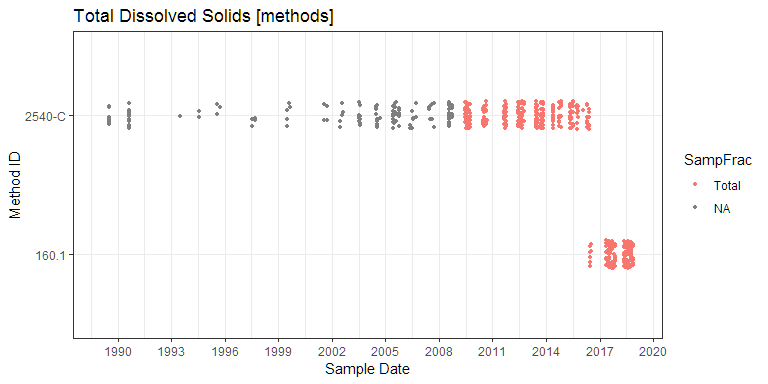

```r
data02 %>% filter(ParamX=="TDS") %>%
  ggplot(.,
         aes(y=SDate,
             x=factor(MethodID),
             col=SampFrac)) + theme_bw() +
  geom_point(na.rm=T,
             position=position_jitter(width=0.1), size=1) +
  xlab("Method ID") + ylab("Sample Date") +
  scale_y_date(date_labels ="%Y",
               date_breaks="3 year",
               limits=c(as.Date("1989-01-01"), as.Date("2019-01-01"))) +
  coord_flip() +
  ggtitle("Total Dissolved Solids [methods]")
```

```r
#
# (
#   data02 %>% filter(ParamX=="TP") %>%
#   ggplot(.,
#          aes(y=SDate,
#              x=factor(MethodID),
#              col=SampFrac)) + theme_bw() +
#   geom_point(na.rm=T,
#              position=position_jitter(width=0.1), size=1) +
#   xlab("Method ID") + ylab("Sample Date") +
#   scale_y_date(date_labels ="%Y",
#                date_breaks="3 year",
#                limits=c(as.Date("1989-01-01"), as.Date("2019-01-01"))) +
#   coord_flip() +ggtitle("Total P [digest]")
# ) %>% ggsave("UTLK_DP_methods_date_01.jpg", ., height=4, width=10, dpi=500)
```

### PARAM.02 Total Suspended Solids

```r
data02 %>% filter(ParamX=="TSS") %>%
  {addmargins(table(.$samp_YRqtr, .$MethodID, useNA="ifany", deparse.level = 2))} %>%
  htmlTable::htmlTable(., css.cell = rbind(rep("padding-left: 0.8em; padding-right: 0.8em;font-size: 0.75em;", times=ncol(.)+1), matrix("padding-left: 0.75em; padding-right: 0.75em; font-size: 0.75em;", ncol=ncol(.)+1, nrow=nrow(.))))
```

|  | .$MethodID 160.2 | .$MethodID 2540-D |  | Sum |
| --- | --- | --- | --- | --- |
| .$samp_YRqtr |  |  |  |  |
| 1978.q03 | 0 | 6 |  | 6 |
| 1989.q03 | 0 | 11 |  | 11 |
| 1990.q03 | 0 | 38 |  | 38 |
| 1990.q04 | 0 | 42 |  | 42 |
| 1991.q02 | 0 | 15 |  | 15 |
| 1991.q03 | 0 | 63 |  | 63 |
| 1993.q03 | 0 | 5 |  | 5 |
| 1994.q03 | 0 | 2 |  | 2 |
| 1995.q03 | 0 | 7 |  | 7 |
| 1997.q03 | 0 | 12 |  | 12 |
| 1999.q03 | 0 | 13 |  | 13 |
| 2001.q03 | 11 | 0 |  | 11 |
| 2002.q02 | 6 | 0 |  | 6 |
| 2002.q03 | 11 | 0 |  | 11 |
| 2002.q04 | 3 | 0 |  | 3 |
| 2003.q03 | 12 | 0 |  | 12 |
| 2004.q02 | 5 | 0 |  | 5 |
| 2004.q03 | 8 | 0 |  | 8 |
| 2005.q02 | 7 | 0 |  | 7 |
| 2005.q03 | 16 | 0 |  | 16 |
| 2006.q02 | 10 | 0 |  | 10 |
| 2006.q03 | 14 | 0 |  | 14 |
| 2007.q02 | 7 | 0 |  | 7 |
| 2007.q03 | 20 | 0 |  | 20 |
| 2008.q03 | 25 | 0 |  | 25 |
| 2009.q02 | 9 | 0 |  | 9 |
| 2009.q03 | 27 | 0 |  | 27 |
| 2009.q04 | 9 | 0 |  | 9 |
| 2010.q02 | 9 | 0 |  | 9 |
| 2010.q03 | 19 | 0 |  | 19 |
| 2011.q03 | 18 | 0 |  | 18 |
| 2011.q04 | 9 | 0 |  | 9 |
| 2012.q02 | 9 | 0 |  | 9 |
| 2012.q03 | 27 | 0 |  | 27 |
| 2012.q04 | 4 | 0 |  | 4 |
| 2013.q02 | 16 | 0 |  | 16 |
| 2013.q03 | 36 | 0 |  | 36 |
| 2013.q04 | 12 | 0 |  | 12 |
| 2014.q02 | 16 | 0 |  | 16 |
| 2014.q03 | 23 | 0 |  | 23 |
| 2014.q04 | 7 | 0 |  | 7 |
| 2015.q02 | 18 | 0 |  | 18 |
| 2015.q03 | 14 | 0 |  | 14 |
| 2015.q04 | 3 | 0 |  | 3 |
| 2016.q01 | 1 | 0 |  | 1 |
| 2016.q02 | 20 | 0 |  | 20 |
| 2017.q02 | 20 | 0 |  | 20 |
| 2017.q03 | 30 | 0 |  | 30 |
| 2017.q04 | 19 | 0 |  | 19 |
| 2018.q02 | 20 | 0 |  | 20 |
| 2018.q03 | 30 | 0 |  | 30 |
| 2018.q04 | 18 | 0 |  | 18 |
| Sum | 598 | 214 |  | 812 |

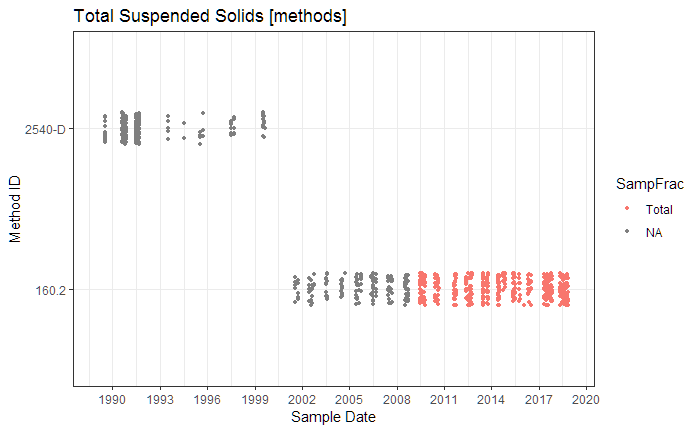

```r
data02 %>% filter(ParamX=="TSS") %>%
  ggplot(.,
         aes(y=SDate,
             x=factor(MethodID),
             col=SampFrac)) + theme_bw() +
  geom_point(na.rm=T,
             position=position_jitter(width=0.1), size=1) +
  xlab("Method ID") + ylab("Sample Date") +
  scale_y_date(date_labels ="%Y",
               date_breaks="3 year",
               limits=c(as.Date("1989-01-01"), as.Date("2019-01-01"))) +
  coord_flip() +
  ggtitle("Total Suspended Solids [methods]")
```

### PARAM.03 Total Volatile Solids

```r
data02 %>% filter(ParamX=="TVS") %>%
  {addmargins(table(.$samp_YRqtr, .$MethodID, useNA="ifany", deparse.level = 2))} %>%
  htmlTable::htmlTable(., css.cell = rbind(rep("padding-left: 0.8em; padding-right: 0.8em;font-size: 0.75em;", times=ncol(.)+1), matrix("padding-left: 0.75em; padding-right: 0.75em; font-size: 0.75em;", ncol=ncol(.)+1, nrow=nrow(.))))
```

|  | .$MethodID 160.4 | .$MethodID 2540-E |  | Sum |
| --- | --- | --- | --- | --- |
| .$samp_YRqtr |  |  |  |  |
| 1990.q04 | 0 | 21 |  | 21 |
| 1991.q01 | 0 | 16 |  | 16 |
| 1991.q02 | 0 | 102 |  | 102 |
| 1991.q03 | 0 | 65 |  | 65 |
| 1993.q03 | 0 | 5 |  | 5 |
| 1995.q03 | 0 | 7 |  | 7 |
| 1997.q03 | 0 | 12 |  | 12 |
| 1999.q03 | 0 | 13 |  | 13 |
| 2001.q03 | 11 | 0 |  | 11 |
| 2002.q02 | 6 | 0 |  | 6 |
| 2002.q03 | 11 | 0 |  | 11 |
| 2002.q04 | 3 | 0 |  | 3 |
| 2003.q03 | 12 | 0 |  | 12 |
| 2008.q03 | 25 | 0 |  | 25 |
| 2010.q02 | 9 | 0 |  | 9 |
| 2010.q03 | 18 | 0 |  | 18 |
| 2011.q03 | 9 | 0 |  | 9 |
| 2011.q04 | 9 | 0 |  | 9 |
| 2012.q02 | 9 | 0 |  | 9 |
| 2012.q03 | 27 | 0 |  | 27 |
| 2012.q04 | 4 | 0 |  | 4 |
| 2014.q02 | 16 | 0 |  | 16 |
| 2014.q03 | 23 | 0 |  | 23 |
| 2014.q04 | 7 | 0 |  | 7 |
| 2015.q02 | 18 | 0 |  | 18 |
| 2015.q03 | 14 | 0 |  | 14 |
| 2015.q04 | 3 | 0 |  | 3 |
| 2016.q01 | 1 | 0 |  | 1 |
| 2016.q02 | 20 | 0 |  | 20 |
| 2017.q02 | 20 | 0 |  | 20 |
| 2017.q03 | 30 | 0 |  | 30 |
| 2017.q04 | 19 | 0 |  | 19 |
| 2018.q02 | 20 | 0 |  | 20 |
| 2018.q03 | 30 | 0 |  | 30 |
| 2018.q04 | 18 | 0 |  | 18 |
| Sum | 392 | 241 |  | 633 |

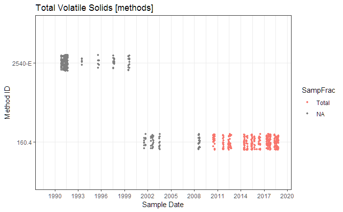

```r
data02 %>% filter(ParamX=="TVS") %>%
  ggplot(.,
         aes(y=SDate,
             x=factor(MethodID),
             col=SampFrac)) + theme_bw() +
  geom_point(na.rm=T,
             position=position_jitter(width=0.1), size=1) +
  xlab("Method ID") + ylab("Sample Date") +
  scale_y_date(date_labels ="%Y",
               date_breaks="3 year",
               limits=c(as.Date("1989-01-01"), as.Date("2019-01-01"))) +
  coord_flip() +
  ggtitle("Total Volatile Solids [methods]")
```

### PARAM.04 Fixed Solids

```r
data02 %>% filter(ParamX=="TFxS") %>%
  {addmargins(table(.$samp_YRqtr, .$MethodID, useNA="ifany", deparse.level = 2))} %>%
  htmlTable::htmlTable(., css.cell = rbind(rep("padding-left: 0.8em; padding-right: 0.8em;font-size: 0.75em;", times=ncol(.)+1), matrix("padding-left: 0.75em; padding-right: 0.75em; font-size: 0.75em;", ncol=ncol(.)+1, nrow=nrow(.))))
```

|  | .$MethodID 2540-E |  | Sum |
| --- | --- | --- | --- |
| .$samp_YRqtr |  |  |  |
| 1991.q01 | 18 |  | 18 |
| 1991.q02 | 87 |  | 87 |
| 1991.q03 | 63 |  | 63 |
| 1993.q03 | 4 |  | 4 |
| 1995.q03 | 7 |  | 7 |
| 1997.q03 | 12 |  | 12 |
| 1999.q03 | 13 |  | 13 |
| 2001.q03 | 11 |  | 11 |
| 2002.q02 | 6 |  | 6 |
| 2002.q03 | 11 |  | 11 |
| 2002.q04 | 3 |  | 3 |
| 2003.q03 | 12 |  | 12 |
| 2008.q03 | 25 |  | 25 |
| Sum | 272 |  | 272 |

- Take a look at Fixed and Volatile solids, combined…

```r
shape_names <- c(
  "circle", paste("circle", c("open", "filled", "cross", "plus", "small")), "bullet",
  "square", paste("square", c("open", "filled", "cross", "plus", "triangle")),
  "diamond", paste("diamond", c("open", "filled", "plus")),
  "triangle", paste("triangle", c("open", "filled", "square")),
  paste("triangle down", c("open", "filled")),
  "plus", "cross", "asterisk"
)
```

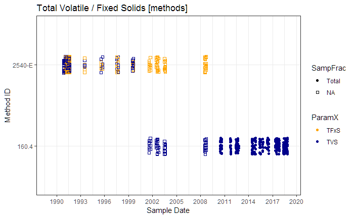

```r
data02 %>% filter(ParamX=="TVS" | ParamX=="TFxS") %>%
  ggplot(.,
         aes(y=SDate,
             x=factor(MethodID),
             color=ParamX, shape=SampFrac)) + theme_bw() +
  geom_point(na.rm=T,
             position=position_jitter(width=0.1), size=1.5) +
  scale_shape_manual(values=c("Total"=19,
                              "Dissolved"=8),
                     na.translate=T,
                     na.value=0) +
  scale_color_manual(values=c("TVS"="darkblue",
                              "TFxS"="orange"),
                     aesthetics = c("color", "fill")) +

  xlab("Method ID") + ylab("Sample Date") +
  scale_y_date(date_labels ="%Y",
               date_breaks="3 year",
               limits=c(as.Date("1989-01-01"), as.Date("2019-01-01"))) +
  coord_flip() +
  ggtitle("Total Volatile / Fixed Solids [methods]")
```

### PARAM.05 Organic C

- Magnitude of Corg in UTLK

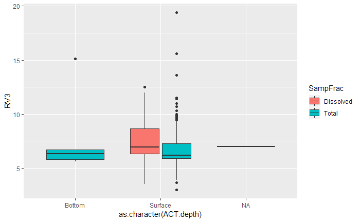

```r
data02 %>% filter(ParamX=="Corg") %>%
  ggplot(.,
         aes(x=as.character(ACT.depth),
             y=RV3,
             fill=SampFrac), na.rm=T) +
  geom_boxplot()
```

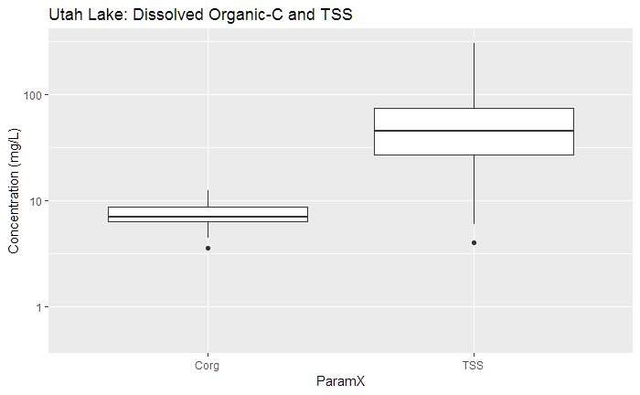

```r
data02 %>% filter((ParamX=="Corg" & SampFrac=="Dissolved") |
                    (ParamX == "TSS")) %>%
  ggplot(., aes(x=ParamX,
                y=RV3), na.rm=T) +
  geom_boxplot(na.rm=T) +
  scale_y_continuous(oob=squish,
                     limits=c(0.5, 300),
                     trans = "log10") +
  ggtitle("Utah Lake: Dissolved Organic-C and TSS") +
  ylab("Concentration (mg/L)")
```

- Quick look at DOC when TSS is low/small

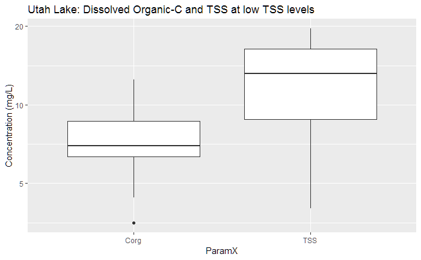

```r
data02 %>% filter((ParamX=="Corg" & SampFrac=="Dissolved") |
                    (ParamX == "TSS" & RV2 < 20)) %>%
  ggplot(., aes(x=ParamX,
                y=RV3), na.rm=T) +
  geom_boxplot(na.rm=T) +
  scale_y_continuous(oob=squish,
                     limits=c(NA, NA),
                     trans = "log10") +
  ggtitle("Utah Lake: Dissolved Organic-C and TSS at low TSS levels") +
  ylab("Concentration (mg/L)")
```

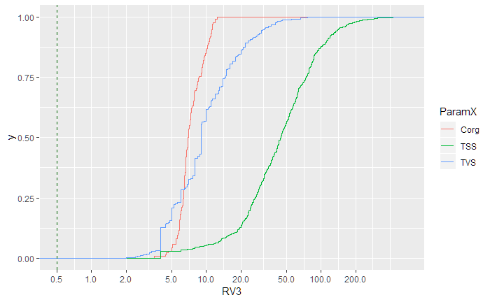

```r
data02 %>% filter((ParamX=="Corg" & SampFrac=="Dissolved") |
                    (ParamX == "TSS") |
                    (ParamX == "TVS")) %>%
  ggplot(., aes(x=RV3), na.rm=T) +
  stat_ecdf(aes(col=ParamX),
            na.rm=T) +
  scale_x_continuous(trans="log10",
                     limits=c(NA, NA),
                     breaks=c(0.5, 1, 2, 5, 10, 20, 50, 100, 200)) +
  geom_vline(xintercept = 0.5, lty=2, color="darkgreen")
```

```r
NA
```

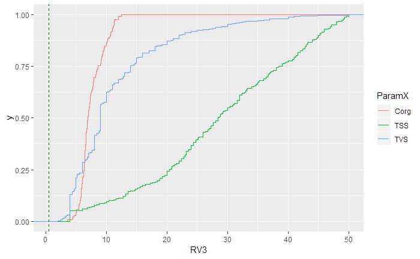

```r
data02 %>% filter((ParamX=="Corg" & SampFrac=="Dissolved") |
                    (ParamX == "TSS") |
                    (ParamX == "TVS")) %>%
  ggplot(., aes(x=RV3), na.rm=T) +
  stat_ecdf(aes(col=ParamX),
            na.rm=T) +
  scale_x_continuous(limits=c(NA, 50)) +
  geom_vline(xintercept = 0.5, lty=2, color="darkgreen")
```

```r
NA
```

### 2.2 Frequency of Data below RL

```r
data02 %>% filter(ParamX %in% c("TSS", "TVS", "Corg")) %>%
  group_by(ParamX, MethodID, SampFrac) %>%
  summarise(Obs = n(),
            p_NonDet = sum(is.na(RV2)),
            min_RL = signif(min(LRL, na.rm=T), digits=3),
            max_RL = signif(max(LRL, na.rm=T), digits=3),
            "10%ile" = signif(quantile(RV3,probs = 0.1, na.rm=T), digits =2),
            "25%ile" = signif(quantile(RV3,probs = 0.25, na.rm=T), digits =2),
            "median" = signif(quantile(RV3,probs = 0.5, na.rm=T), digits =2),
            "75%ile" = signif(quantile(RV3,probs = 0.75, na.rm=T), digits =2),
            "90%ile" = signif(quantile(RV3,probs = 0.9, na.rm=T), digits =2)
            ) -> Solids_RL_tab01
#
Solids_RL_tab01 %<>% mutate(
  NonDet_total = paste(round(p_NonDet / Obs, digits=2)*100,
                       " %", sep="")
  ) %>%
  select(ParamX:p_NonDet, NonDet_total, everything()) %>%
  mutate(
    min_RL = case_when(
      min_RL == "Inf" ~ as.numeric(NA),
      !is.na(min_RL) ~ min_RL),
    max_RL = case_when(
      max_RL == "-Inf" ~ as.numeric(NA),
      !is.na(max_RL) ~ max_RL
    )
  )

# openxlsx::write.xlsx(DP_RL_tab01, file="DP_reportlimits_table1.xlsx")
```

```r
Solids_RL_tab01 %>%
  htmlTable::htmlTable(., css.cell = rbind(rep("padding-left: 0.8em; padding-right: 0.8em;font-size: 0.75em;", times=ncol(.)+1), matrix("padding-left: 0.8em; padding-right: 0.8em; font-size: 0.75em;", ncol=ncol(.)+1, nrow=nrow(.))), n.tspanner=c(3,3,3), tspanner=c("","",""), align=c("rclc|ccc|cc|ccccc"))
```

|  | ParamX | MethodID | SampFrac | Obs | p_NonDet | NonDet_total | min_RL | max_RL | 10%ile | 25%ile | median | 75%ile | 90%ile |
| --- | --- | --- | --- | --- | --- | --- | --- | --- | --- | --- | --- | --- | --- |
| 1 | Corg | 5310-B | Dissolved | 138 | 0 | 0 % | 0.5 | 0.5 | 5.7 | 6.3 | 7 | 8.6 | 11 |
| 2 | Corg | 5310-B | Total | 138 | 0 | 0 % | 0.5 | 0.5 | 5.3 | 5.9 | 6.1 | 7.2 | 8.4 |
| 3 | Corg | GENERIC METHOD | Total | 18 | 0 | 0 % |  |  | 5.7 | 6 | 7 | 9 | 13 |
| 4 | TSS | 160.2 |  | 155 | 15 | 10 % | 4 | 4 | 4 | 11 | 28 | 49 | 75 |
| 5 | TSS | 160.2 | Total | 443 | 2 | 0 % | 4 | 4 | 20 | 27 | 41 | 62 | 95 |
| 6 | TSS | 2540-D |  | 214 | 0 | 0 % |  |  | 26 | 45 | 75 | 100 | 160 |
| 7 | TVS | 160.4 |  | 68 | 33 | 49 % | 9 | 9 | 9 | 9 | 9 | 19 | 34 |
| 8 | TVS | 160.4 | Total | 324 | 67 | 21 % | 4 | 9 | 4 | 4.8 | 7 | 10 | 17 |
| 9 | TVS | 2540-E |  | 241 | 7 | 3 % |  |  | 6 | 8 | 12 | 18 | 26 |

### 2.3 Sample Fraction Effects

```r
data02 %>% filter(ParamX=="Corg") %>%
  {table(.$ParamX, .$SampFrac, useNA="ifany", deparse.level = 2)}
```

```
        .$SampFrac
.$ParamX Dissolved Total
    Corg       138   156
```

```r
data02 %>% filter(ParamX=="Corg") %>%
  {table(.$ParamX, .$ACT.depth, useNA="ifany", deparse.level = 2)}
```

```
        .$ACT.depth
.$ParamX Bottom Surface <NA>
    Corg      5     288    1
```

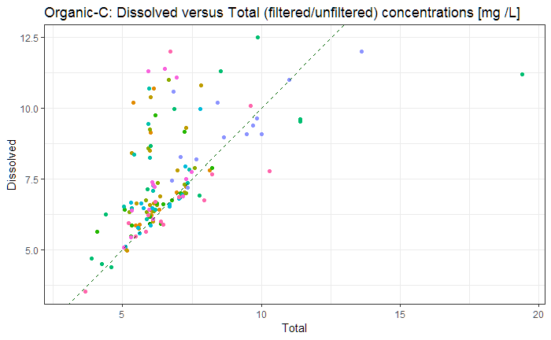

```r
data02 %>%
  filter(ParamX=="Corg" & ACT.depth != "Bottom") %>%
  distinct(MLID, ParamX, SDate, SampFrac, RV2, ACT.depth,
         MethodID) %>%
  spread(., SampFrac, RV2) %>%
  ggplot(.,
         aes(x=Total, y=Dissolved,
             col=MLID)) + theme_bw() +
  geom_point(na.rm=T) + theme(legend.position = "none") +
  ggtitle("Organic-C: Dissolved versus Total (filtered/unfiltered) concentrations [mg /L]") +
  geom_abline(slope=1, intercept=0, lty=2, col="darkgreen") +
  scale_x_continuous(limits=c(NA, NA), oob=squish) +
  scale_y_continuous(limits=c(NA, NA), oob=squish)
```

### “TVS” vs TSS

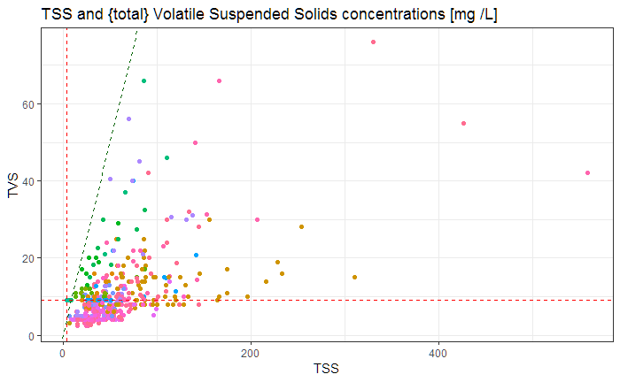

```r
data02 %>%
  filter((ParamX=="TVS" | ParamX=="TSS") & ACT.depth != "Bottom") %>%
  distinct(MLID, ParamX, SDate, SampFrac, ACT.depth, RV3) %>%
  spread(., ParamX, RV3) %>%
  ggplot(.,
         aes(x=TSS, y=TVS,
             col=as.factor(lubridate::year(SDate)))) + theme_bw() +
  geom_point(na.rm=T) + theme(legend.position = "none") +
  ggtitle("TSS and {total} Volatile Suspended Solids concentrations [mg /L]") +
  geom_abline(slope=1, intercept=0, lty=2, col="darkgreen") +
  scale_x_continuous(limits=c(NA, NA), oob=squish) +
  scale_y_continuous(limits=c(NA, NA), oob=squish) +
  geom_hline(yintercept = 9, lty=2, col="red") +
  geom_vline(xintercept = 4, lty=2, col="red")
```

### VSS:TSS ratios

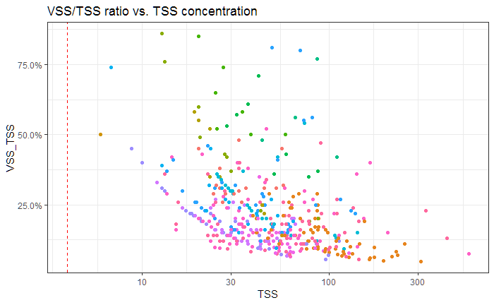

```r
data02 %>%
  filter((ParamX=="TVS" | ParamX=="TSS") & ACT.depth != "Bottom") %>%
  distinct(MLID, ParamX, SDate, SampFrac, ACT.depth, RV3) %>%
  spread(., ParamX, RV3) %>%
  filter(!is.na(TSS) & !is.na(TVS)) %>%
  mutate(
    VSS_TSS = case_when(
      TVS > TSS ~ as.numeric(NA),
      TVS == TSS ~ 1.0,
      TRUE ~ signif((TVS / TSS), digits = 2))
    ) %>%
  ggplot(.,
         aes(x=TSS, y=VSS_TSS,
             col=as.factor(lubridate::year(SDate)))) + theme_bw() +
  geom_point(na.rm=T) + theme(legend.position = "none") +
  ggtitle("VSS/TSS ratio vs. TSS concentration") +
  scale_x_continuous(limits=c(NA, NA), oob=squish, trans="log10") +
  scale_y_continuous(limits=c(NA, NA), oob=squish, labels = percent) +
  geom_vline(xintercept = 4, lty=2, col="red")
```

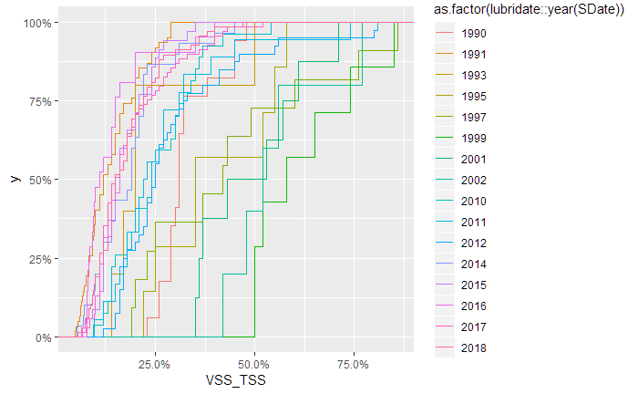

```r
data02 %>%
  filter((ParamX=="TVS" | ParamX=="TSS") & ACT.depth != "Bottom") %>%
  distinct(MLID, ParamX, SDate, SampFrac, ACT.depth, RV3) %>%
  spread(., ParamX, RV3) %>% filter(!is.na(TSS) & !is.na(TVS)) %>%
  mutate(
    VSS_TSS = case_when(
      TVS > TSS ~ as.numeric(NA),
      TVS == TSS ~ 1.0,
      TRUE ~ signif((TVS / TSS), digits = 2))
    ) %>%
  ggplot(., aes(x=VSS_TSS), na.rm=T) +
  stat_ecdf(aes(col=as.factor(lubridate::year(SDate))),
            na.rm=T) +
  scale_x_continuous(limits=c(NA, NA), labels=percent) +
  scale_y_continuous(labels=percent)
```

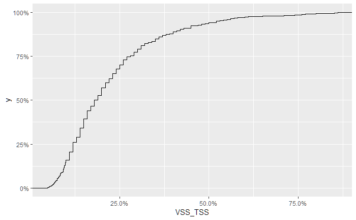

```r
data02 %>%
  filter((ParamX=="TVS" | ParamX=="TSS") & ACT.depth != "Bottom") %>%
  distinct(MLID, ParamX, SDate, SampFrac, ACT.depth, RV3) %>%
  spread(., ParamX, RV3) %>% filter(!is.na(TSS) & !is.na(TVS)) %>%
  mutate(
    VSS_TSS = case_when(
      TVS > TSS ~ as.numeric(NA),
      TVS == TSS ~ 1.0,
      TRUE ~ signif((TVS / TSS), digits = 2))
    ) %>%
  ggplot(., aes(x=VSS_TSS), na.rm=T) +
  stat_ecdf(na.rm=T) +
  scale_x_continuous(limits=c(NA, NA), labels=percent) +
  scale_y_continuous(labels=percent)
```

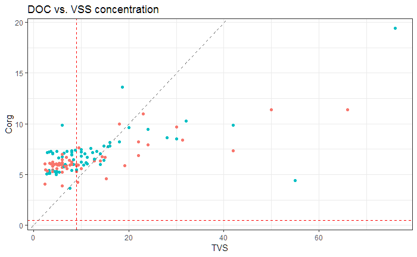

```r
data02 %>%
  filter((ParamX=="TVS" | ParamX=="Corg") & ACT.depth != "Bottom") %>%
  distinct(MLID, ParamX, SDate, SampFrac, ACT.depth, RV3) %>%
  spread(., ParamX, RV3) %>% filter(!is.na(Corg) & !is.na(TVS)) %>%
  ggplot(.,
         aes(x=TVS, y=Corg,
             col=as.factor(lubridate::year(SDate)))) + theme_bw() +
  geom_point(na.rm=T) + theme(legend.position = "none") +
  ggtitle("DOC vs. VSS concentration") +
  scale_x_continuous(limits=c(NA, NA), oob=squish) +
  scale_y_continuous(limits=c(NA, NA), oob=squish) +
  geom_vline(xintercept = 9, lty=2, col="red") +
  geom_hline(yintercept = 0.5, lty=2, col="red") +
  geom_abline(slope=0.5, intercept=0, lty=2, col="grey40")
```

## END

### Working pieces

```r
# select(EDD2_2, contains("key", ignore.case=T)) %>% names(.)
```

**Start work date ::** 190809  
**Last work date ::** 190809  
**Current review date ::** 190809

eof